# Estimating the Effect of a Job-Training Program with Propensity Score Methods

Ka Man (Christie) Fung

October 30, 2026

## 1. Question

Did participation in a job-training program (the National Supported Work Demonstration) raise participants’ **1978 earnings**, compared with similar people who did not participate?

This is a short, reproducible example of a policy-evaluation workflow with observational data: define the estimand, check whether the groups are comparable, adjust with more than one method, and test how much the answer depends on the method.

**Data.** The `lalonde` dataset that ships with the `MatchIt` package (a version of the classic LaLonde 1986 data in which the comparison group comes from a national survey, not a randomized control group). It is public and requires no download.

**Estimand.** The average treatment effect on the treated (ATT): the effect for people who actually took part in the program.

## 2. Data

```r
data("lalonde", package = "MatchIt")
dat <- lalonde
covs <- c("age", "educ", "race", "married", "nodegree", "re74", "re75")

dat %>%
  group_by(treat) %>%
  summarise(n = n(),
            age = mean(age), educ = mean(educ),
            pct_married = mean(married), pct_nodegree = mean(nodegree),
            re74 = mean(re74), re75 = mean(re75), re78 = mean(re78))
```

| treat | n | age | educ | pct_married | pct_nodegree | re74 | re75 | re78 |
| --- | --- | --- | --- | --- | --- | --- | --- | --- |
| 0 | 429 | 28.03030 | 10.23543 | 0.5128205 | 0.5967366 | 5619.237 | 2466.484 | 6984.170 |
| 1 | 185 | 25.81622 | 10.34595 | 0.1891892 | 0.7081081 | 2095.574 | 1532.055 | 6349.144 |

`treat` = 1 for program participants. `re74`, `re75` and `re78` are earnings in 1974, 1975 (before the program) and 1978 (after it).

## 3. Naive comparison

Simply comparing average 1978 earnings ignores the fact that the groups differ before the program.

```r
fit_naive <- lm(re78 ~ treat, data = dat)
coeftest(fit_naive, vcov = vcovHC(fit_naive, type = "HC3"))
```

```
##
## t test of coefficients:
##
##             Estimate Std. Error t value Pr(>|t|)
## (Intercept)  6984.17     352.58 19.8089   <2e-16 ***
## treat        -635.03     678.75 -0.9356   0.3499
## ---
## Signif. codes:  0 '***' 0.001 '**' 0.01 '*' 0.05 '.' 0.1 ' ' 1
```

## 4. Are the groups comparable?

Standardized mean differences (SMD) measure imbalance on each covariate. A common rule of thumb is that an absolute SMD below 0.1 indicates good balance.

```r
bal.tab(treat ~ age + educ + race + married + nodegree + re74 + re75,
        data = dat, binary = "std", un = TRUE, thresholds = c(m = 0.1))
```

[output not shown]

## 5. Propensity score matching

I estimate propensity scores with logistic regression, then match each treated unit to a control with a close score (1:1 nearest neighbor, caliper of 0.2 standard deviations).

```r
m_out <- matchit(treat ~ age + educ + race + married + nodegree + re74 + re75,
                 data = dat, method = "nearest", distance = "glm",
                 caliper = 0.2, ratio = 1)
summary(m_out)$nn
```

```
##               Control Treated
## All (ESS)         429     185
## All               429     185
## Matched (ESS)     113     113
## Matched           113     113
## Unmatched         316      72
## Discarded           0       0
```

### Overlap

The treated and control groups need overlapping propensity scores. Where they do not overlap, no method can credibly estimate an effect.

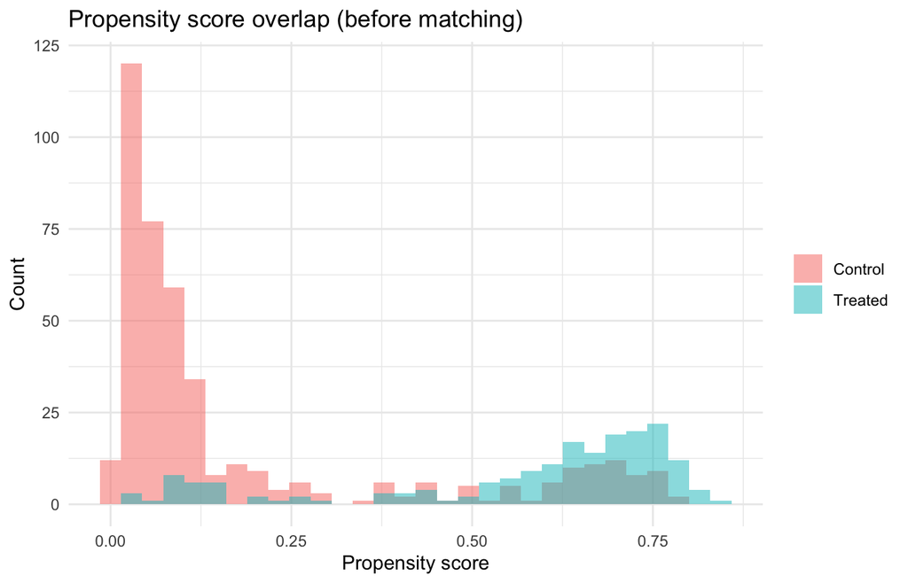

```r
ps_df <- data.frame(ps = m_out$distance, treat = factor(dat$treat, labels = c("Control", "Treated")))
ggplot(ps_df, aes(ps, fill = treat)) +
  geom_histogram(position = "identity", alpha = 0.5, bins = 30) +
  labs(x = "Propensity score", y = "Count", fill = NULL,
       title = "Propensity score overlap (before matching)") +
  theme_minimal()
```

### Balance after matching

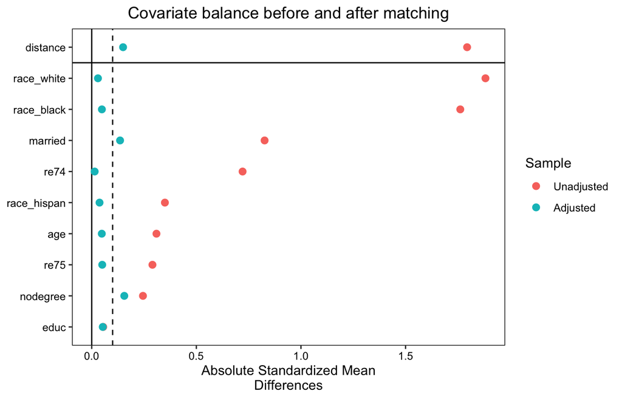

```r
love.plot(m_out, binary = "std", thresholds = c(m = 0.1), abs = TRUE,
          var.order = "unadjusted",
          title = "Covariate balance before and after matching")
```

```r
bal.tab(m_out, binary = "std", thresholds = c(m = 0.1))
```

```
## Balance Measures
##                 Type Diff.Adj        M.Threshold
## distance    Distance   0.1499
## age          Contin.   0.0482     Balanced, <0.1
## educ         Contin.   0.0528     Balanced, <0.1
## race_black    Binary   0.0487     Balanced, <0.1
## race_hispan   Binary  -0.0374     Balanced, <0.1
## race_white    Binary  -0.0299     Balanced, <0.1
## married       Binary  -0.1356 Not Balanced, >0.1
## nodegree      Binary   0.1557 Not Balanced, >0.1
## re74         Contin.  -0.0141     Balanced, <0.1
## re75         Contin.  -0.0503     Balanced, <0.1
##
## Balance tally for mean differences
##                    count
## Balanced, <0.1         7
## Not Balanced, >0.1     2
##
## Variable with the greatest mean difference
##  Variable Diff.Adj        M.Threshold
##  nodegree   0.1557 Not Balanced, >0.1
##
## Sample sizes
##           Control Treated
## All           429     185
## Matched       113     113
## Unmatched     316      72
```

Note: 2 were still imbalanced. Will address in limitation.

## 6. Estimating the effect

For the matched sample I use a regression with the covariates included (doubly robust adjustment) and standard errors clustered on matched pair.

```r
md <- match.data(m_out)
fit_match <- lm(re78 ~ treat + age + educ + race + married + nodegree + re74 + re75,
                data = md, weights = weights)
est_match <- coeftest(fit_match, vcov = vcovCL(fit_match, cluster = md$subclass))
est_match["treat", ]
```

```
##    Estimate  Std. Error     t value    Pr(>|t|)
## 1510.982442  973.187870    1.552611    0.121980
```

## 7. How sensitive is the answer to the method?

A result that holds across reasonable methods is more believable than one that appears under only one specification. I compare four estimates:

1. Naive difference in means
2. Regression adjustment alone
3. Propensity score weighting (inverse-probability, ATT weights)
4. Matching + regression (from above)

```r
# 2. Regression adjustment
fit_reg <- lm(re78 ~ treat + age + educ + race + married + nodegree + re74 + re75, data = dat)
est_reg <- coeftest(fit_reg, vcov = vcovHC(fit_reg, type = "HC3"))

# 3. ATT weighting: treated get weight 1, controls get ps / (1 - ps)
ps_fit <- glm(treat ~ age + educ + race + married + nodegree + re74 + re75,
              data = dat, family = binomial())
ps <- fitted(ps_fit)
dat$w_att <- ifelse(dat$treat == 1, 1, ps / (1 - ps))
fit_ipw <- lm(re78 ~ treat, data = dat, weights = w_att)
est_ipw <- coeftest(fit_ipw, vcov = vcovHC(fit_ipw, type = "HC3"))

get_row <- function(label, est) {
  data.frame(Method = label,
             Estimate = est["treat", "Estimate"],
             SE = est["treat", "Std. Error"],
             Lower95 = est["treat", "Estimate"] - 1.96 * est["treat", "Std. Error"],
             Upper95 = est["treat", "Estimate"] + 1.96 * est["treat", "Std. Error"])
}

results <- bind_rows(
  get_row("Naive difference", coeftest(fit_naive, vcov = vcovHC(fit_naive, type = "HC3"))),
  get_row("Regression adjustment", est_reg),
  get_row("ATT weighting", est_ipw),
  get_row("Matching + regression", est_match)
)
results %>% mutate(across(where(is.numeric), ~ round(.x, 0)))
```

| Method | Estimate | SE | Lower95 | Upper95 |
| --- | --- | --- | --- | --- |
| Naive difference | -635 | 679 | -1965 | 695 |
| Regression adjustment | 1548 | 750 | 78 | 3018 |
| ATT weighting | 1214 | 831 | -416 | 2844 |
| Matching + regression | 1511 | 973 | -396 | 3418 |

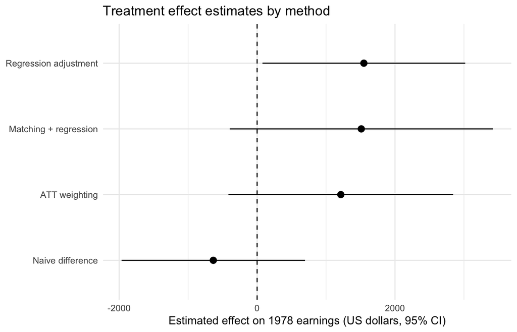

```r
ggplot(results, aes(x = Estimate, y = reorder(Method, Estimate))) +
  geom_vline(xintercept = 0, linetype = "dashed") +
  geom_pointrange(aes(xmin = Lower95, xmax = Upper95)) +
  labs(x = "Estimated effect on 1978 earnings (US dollars, 95% CI)", y = NULL,
       title = "Treatment effect estimates by method") +
  theme_minimal()
```

## 9. Limitations

- **Unobserved confounding.** Matching and weighting adjust only for the variables measured here. If participants differed on unmeasured traits such as motivation, the estimates could still be biased.
- **Imbalanced matching.** After matching, seven of nine covariates were balanced (absolute standardized mean difference below 0.1). Marital status (−0.14) and lack of a high school degree (0.16) remained modestly imbalanced; both were included as covariates in the outcome regression to reduce residual bias. The caliper also excluded 72 of 185 treated units for which no close comparison unit was available, so the matching estimate applies to the 113 matched participants and may differ from the effect for all participants.
- **Positivity.** Estimates are credible only where treated and control units have overlapping propensity scores; see the overlap plot.
- **Model choice.** Results can depend on the covariates, caliper and weighting scheme. Section 7 is a partial check, not proof of robustness.
- **Illustration only.** This example shows a workflow on a well-known public dataset. It is not a new evaluation of the original program.